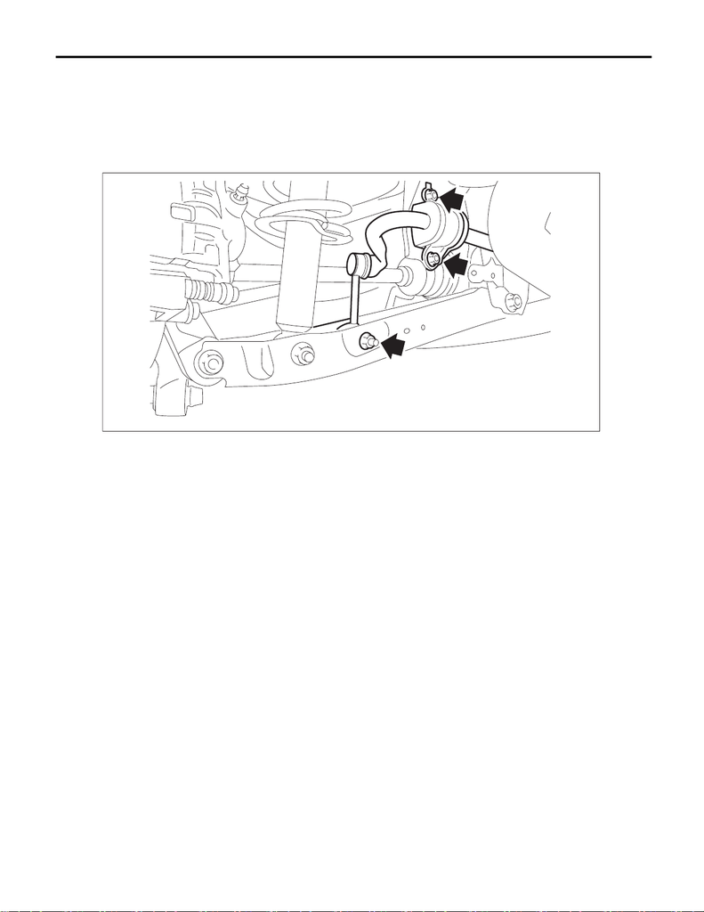

RS-14

Rear Stabilizer

REAR SUSPENSION

4. Rear Stabilizer

A: REMOVAL

1) Lift up the vehicle, and then remove the rear wheels.

2) Remove the rear stabilizer.

(1) Remove the nut and disconnect the right and left stabilizer link assemblies.

(2) Detach the right and left clamps - stabilizer bushing and remove the rear stabilizer.

RS-00351

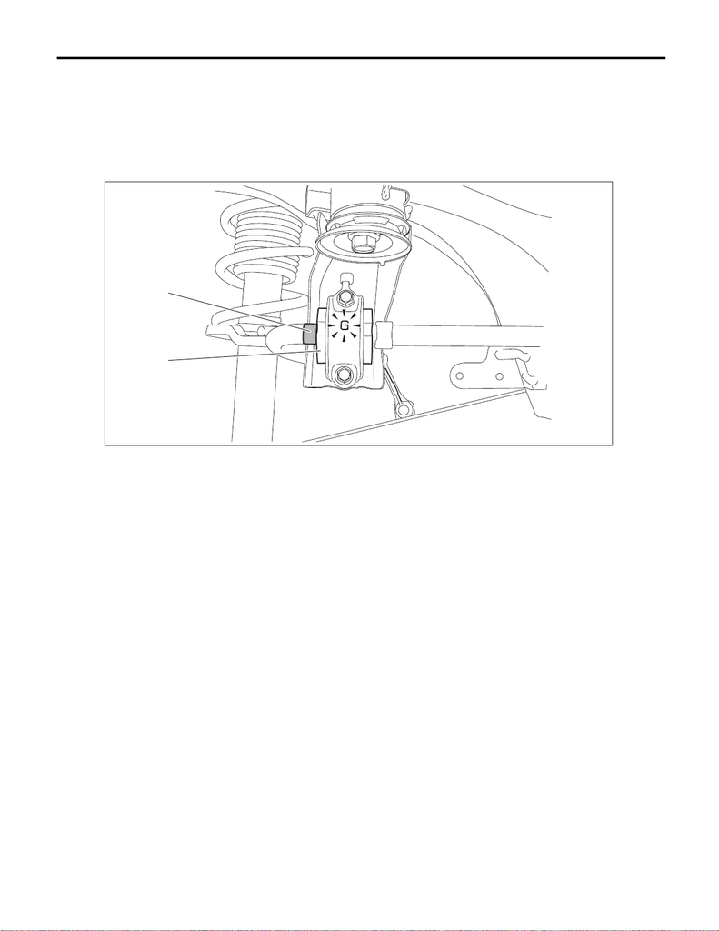

RS-15

Rear Stabilizer

REAR SUSPENSION

B: INSTALLATION

CAUTION:

• For parts which are not reusable, always use new parts.

full contact with the ground.

• Install the clamp - stabilizer bushing with the “G” character facing upward.

• When installing, align the edge of identification paint (a) to the end face of the bushing (b).

1) Before installation, inspect the following items and replace any faulty part with a new one.

• Check the bushing - stabilizer for abnormal cracks, fatigue or damage.

• Check the stabilizer link assembly for damage.

2) Install the rear stabilizer.

Tightening torque:

Clamp - stabilizer bushing: 30 N·m (3.1 kgf-m, 22.1 ft-lb)

Stabilizer link assembly: 38 N·m (3.9 kgf-m, 28.0 ft-lb)

3) Install the rear wheels and lower the vehicle.

Tightening torque:

120 N·m (12.2 kgf-m, 88.5 ft-lb)

RS-00415

(a)

(b)